# GROUP 19

## GITHUB REPO LINK:

https://github.com/andre-gnandt/DATA-550-Lab-Group-19

# DATA 550 Lab 4 - Storytelling and visualizing trends and uncertainties

In this lab we will be using both R and Python, and for each question you will develop an answer both in `ggplot` and in `Altair`. Although the `%%R` cell magic makes it convenient for us to do this in the same notebook, I would still recommend that you use a separate Jupyter Notebook with a dedicated R kernel or RStudio to develop your R code. The reasons for this are that autocompletion works better there and the error messages are easier to understand. Once you have developed the code for a question you can paste it into the corresponding R cell here and make sure it runs and shows up in the exported HTML.

If your `rpy2` does not work, you can paste in entire cells from an R-kernel including the output plots, or you can submit a different notebook on GitHub for the R part, but you must write this in the canvas comments or next to your repo link in this notebook so that the TAs know when they grade.

## Submission instructions

rubric={mechanics:2}

You receive marks for submitting your lab correctly, please follow these instructions:

- Create a GitHub Repo for your group.
  - Keep this organized, i.e. with a separate clearly marked folder for each assignment.
- [Click here to view a description of the rubrics used to grade the questions](https://github.com/UBC-MDS/public/tree/master/rubric)
- Push your `.ipynb` file to your GitHub repository for this lab.
- Include a clickable link to your GitHub repo for the lab just below this cell
  - It should look something like this https://github.ubc.ca/folder_path/DATA_550_labX_groupY.
- Upload a `.html` version of your assignment to Canvas.
  - Run all cells in your notebook to make sure there are no errors by doing `Kernel -> Restart Kernel and Run All Cells...`
  - Convert your notebook to .html format using `File -> Save and Export Notebook As -> HTML`
  - Submit and double check that your have submitted the correct file to Canvas

# 0. The back story

*(If you don't like the back stories, you can jump down to the heading "The data" Also a disclaimer that I am not a linguist, so this lab is my understanding of some articles I have read, it is likely not perfect.)*

First, I just want to thank you for bringing me back to my senses and stopping my world domination attempt and silly startup idea. I don't know what happen, but I clearly wasn't myself there for a while. Now that you have brought me back to normal, I would like design this lab more similar to the first one and go through a topic that I find intriguing and ponder-worthy.

This time, instead of looking around us, we will look inside. Ever since I arrived on this planet, I have been fascinated about your use of airborn oscillations to transmit information generated by electrical impulses. And the fact that you rely on muscular dexterity for the encoding process as well as passive mechnotransduction for the decoding is truly remarkable (in a primitive sense of course, I guess how your kind can appreciate "the remarkable complexity" of a cave painting). Such a system is clearly a bottleneck in terms of information bandwidth and I am surprised a more direct means of intercranial transmission never evolved here, but from the perspective of my research on less evolved galactic lifeforms I find this fascinating!

After hearing that there are over 7,000 languages spoken across this globe, I am curious whether some of these at least allow for more rapid information transmission than others. The implications of this reach beyond just communication as I have recently learned that you also restrict many of your thoughts to those that can be expressed in words (again, fascinating!). This means that you could literally upgrade your thought throughput by learning a new language. And it could mean that there are groups of people who have access to faster thinking others, just because their language can convey information at a higher rate, what an enormous advantage!

## The data

To aid our exploration of whether some languages are more efficient at conveying information than others, I have received assistance from some of your finest scientists. The data in this lab was published as part of a study in Science Advances in 2019 and made publicly available in their online repository. If you want to read part of the article, I recommend that you do it after attempting to answer the questions (or if you get stuck) since it will give away some of the things that we can otherwise "discover" ourselves. There is also a popular science version of this article publish in The Economist, and I link to both in the optional question at the end.

The scientists have compiled two tables, one with general information on the languages we are studying and one with experimental data where they recorded people speaking a certain text in different languages and noted down how fast they spoke, etc. You can find a description of the columns of both datasets below and they are available both in the student repo and on OneDrive.

### Languages dataset

| Column | Description |
| --- | --- |
| iso_lang | ISO_639-3 language code |
| language | Language name |
| information density | Bits of information per syllable in the language |
| distinct_syllables | The number of different syllables in the language |
| continent | The continent where the language is spoken |

### Spoken texts dataset

| Column | Description |
| --- | --- |
| speaker | Speaker ID |
| iso_lang | ISO_639-3 language code |
| text | Text ID |
| sex | The sex of the speaker |
| duration | The number of seconds it took to speak the text |
| syllables | Number of syllables uttered during the speech |
| age | The age of the speaker |

Overall, you will have a bit less direction in this lab to closer simulate a real-life scenario. The questions are a mix of explicit instructions and describing the problem in text, rather than in exact steps. As part of this, there is also a few data wrangling steps needed. As this is an exercise in you interpreting information, it is up to you to clarify what you don't understand with me and the TAs during labs and office hours, just as you would in a real-life collaboration.

```python
# Run this cell to ensure that altair plots show up in the exported HTML
# and that the R cell magic works
import altair as alt

# Save a vega-lite spec and a PNG blob for each plot in the notebook
alt.renderers.enable('mimetype')
# Handle large data sets without embedding them in the notebook
#alt.data_transformers.enable('data_server')
alt.data_transformers.enable("vegafusion")

# Load the R cell magic
%load_ext rpy2.ipython
```

```
Error importing in API mode: ImportError('On Windows, cffi mode "ANY" is only "ABI".')
Trying to import in ABI mode.
```

# 1. Language exploration

Let’s first get familiar with potential differences and similarities between the languages in this data set. Clearly a language's information density is going to be important in how quick a speaker can convey information, but I wonder if number of distinct syllabus matter. Let's see if we can see any patterns by organizing the languages by these two variables.

### Question 1.1

rubric={accuracy:1,visualization:1}

#### Python

1. Create a scatterplot of the information density of each language versus its number of distinct syllabus. Zoom in to the extent of the data instead of forcing zero to be in the axis.
2. You will notice that the data appears to cluster in groups in the scatter plot. Can you find a categorical variable in this dataframe that roughly explains this clustering? Color the points in the plot you just created according that variable and add a suitable trend line for each cluster. If there are any points that seem to be outliers, avoid overfitting the trendline to them.
3. If you think any particular data points deviate from their cluster, label them with their language name in the plot.

```python
# YOUR ANSWER GOES HERE
alt.renderers.enable("default")

import pandas as pd
data = pd.read_csv("languages.csv")

scatter = alt.Chart(data).mark_circle(size=80).encode(
    x=alt.X("distinct_syllables:Q", title="Number of distinct syllables"),
    y=alt.Y("information_density:Q", title="Information density"),
    tooltip=["language:N", "distinct_syllables:Q", "information_density:Q"]
)

points = alt.Chart(data).mark_circle(size=80).encode(
    x="distinct_syllables:Q",
    y="information_density:Q",
    color=alt.Color("continent:N", title="Continent"),
    tooltip=["language:N", "continent:N"]
)

trend = alt.Chart(data).transform_regression("distinct_syllables", "information_density",groupby=["continent"]).mark_line().encode(
    x="distinct_syllables:Q",
    y="information_density:Q",
    color="continent:N"
)

points + trend

labels = alt.Chart(data).mark_text( align="left",dx=5,dy=-5).encode(
    x="distinct_syllables:Q",
    y="information_density:Q",
    text="language:N",
    color="continent:N"
)
plot_A = points + trend + labels
plot_A
```

[interactive chart not shown]

### Question 1.2

rubric={accuracy:1,visualization:1}

#### R

1. Create a scatterplot of the information density of each language versus its number of distinct syllabus.
2. You will notice that the data appears to cluster in groups in the scatter plot. Can you find a categorical variable in this dataframe that roughly explains this clustering? Color the points in the plot you just created according that variable and add a suitable trend line for each cluster (optionally including a confidence interval for the fitted line). If there are any points that seem to be outliers, avoid overfitting the trendline to them.
3. If you think any particular data points deviate from their cluster, label them with their language name in the plot.

```
In addition: Warning messages:
1: package 'ggplot2' was built under R version 4.5.2
2: package 'tibble' was built under R version 4.5.2
3: package 'stringr' was built under R version 4.5.2
```

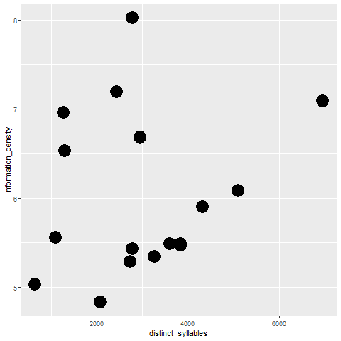

```python
%%R
# YOUR ANSWER GOES HERE
library(tidyverse)
lang <- read.csv("languages.csv")

ggplot(lang, aes(x= distinct_syllables, y= information_density))+geom_point(size = 8)
```

The continent categorical variable seems to explain this:

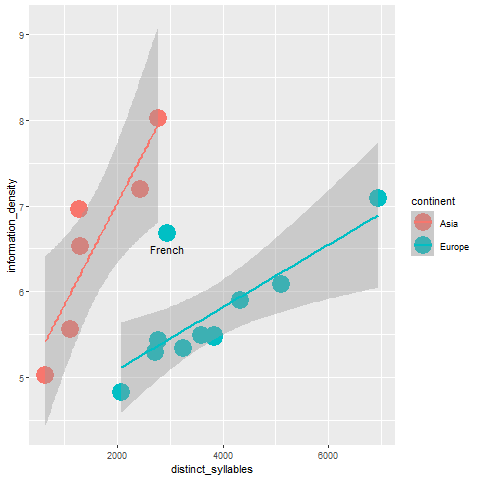

```python
%%R

A <- ggplot(lang,
aes(x= distinct_syllables, y= information_density, color = continent)
)+geom_point(size = 8) + geom_smooth(method = "lm") +annotate('text', label = "French", y = 6.5, x = 2949)
A
```

# 2. Speech rate and information density

Hmm... what an intriguing relationship we just revealed... let’s keep these clusters in mind while exploring whether continuing our exploration. The two variables that directly determine the information rate of a language are its information density (bits of information per syllable) and the rate at which it is spoken (syllables per second). A high value in both would indicate a high information rate and efficient communication (a higher number of information bits conveyed per second).

### Question 2.1

rubric={reasoning:2,accuracy:3}

#### Python

1. While the information density of each language have already been provided to us, we will have to approximate the speech rate (syllables per second) of each language via the `spoken_texts` dataset. Using this data, calculate the average speech rate per language (for now, treat all entries as individual observations, even if some are read by the same person).
2. Create a new column, `speech_rate`, in the `languages` data frame that hold these average values. Since the calculated values are not in the same order as the languages in the `languages` data frame, you cannot simply append it. Instead, you can use the dataframe merge method to join the series of average speech rate values that you just created with the `languages` dataframe. The language ISO codes could be used as the column to merge on.
3. Create a scatter plot of the information density versus the speech rate for the `languages` dataframe. Use the same groupings as in the previous scatter plot you made and add one trend line per group. Label the same points with text labels as in the previous scatterplot. Zoom in to the extent of the data instead of forcing zero to be in the axes.
4. Write a few sentences under the plot describing the relationship you observe. Based on this plot, do speakers of any particular languages appear to be more efficient at conveying information?

```python
# YOUR ANSWER GOES HERE

spoken = pd.read_csv("spoken-texts.csv")
spoken

spoken["speech_rate"] = spoken["syllables"] / spoken["duration"]

avg_speech_rate = (spoken.groupby("iso_lang")["speech_rate"].mean().reset_index())
avg_speech_rate

languages = pd.read_csv("languages.csv")
languages = languages.merge(avg_speech_rate, on="iso_lang",how="left")
languages


points = alt.Chart(languages).mark_circle(size=80).encode(
    x=alt.X("speech_rate:Q", title="Speech rate (syllables per second)"),
    y=alt.Y("information_density:Q", title="Information density"),
    color=alt.Color("continent:N", title="Continent"),
    tooltip=["language:N", "continent:N"]
)

trend = alt.Chart(languages).transform_regression("speech_rate","information_density",groupby=["continent"]).mark_line().encode(
    x="speech_rate:Q",
    y="information_density:Q",
    color="continent:N"
)
points + trend

labels = alt.Chart(languages).mark_text(align="left",dx=5,dy=-5).encode(
    x="speech_rate:Q",
    y="information_density:Q",
    text="language:N",
    color="continent:N"
)
plot_B = points + trend + labels
plot_B
```

[interactive chart not shown]

### Question 4:

There does not appear to be a noticeable or considerable difference in the rate to which they convey information between any of the languages. They all appear to generally be under some information rate upper bound, as we can see that faster speakers have lower information density (they have to speak faster to convey as much info as the high info-dense languages) and vise versa.

### Question 2.2

rubric={reasoning:2,accuracy:3}

#### R

1. While the information density of each language have already been provided to us, we will have to approximate the speech rate (syllables per second) of each language via the `spoken_texts` dataset. Using this data, calculate the average speech rate per language (for now, treat all entries as individual observations, even if some are read by the same person).
2. Create a new column, `speech_rate`, in the `languages` data frame that hold these average values. Since the calculated values are not in the same order as the languages in the `languages` data frame, you cannot simply append it. Instead, you need to use the `inner_join` function to merge the dataframe of average speech rate values that you just created with the `languages` dataframe. The language ISO codes could be used as the column to join on.
3. Create a scatter plot of the information density versus the speech rate for the `languages` dataframe. Use the same groupings as in the previous scatter plot you made and add one trend line per group. Label the same points with text labels as in the previous scatterplot.

```python
%%R
library(dplyr)
```

```python
%%R
spoken <- read.csv("spoken-texts.csv")
spoken$speech_rate_individual <- spoken$syllables/spoken$duration

mean_rates <- spoken %>%
    group_by(iso_lang) %>%
    summarize(speech_rate = mean(speech_rate_individual, na.rm = TRUE))

lang <- inner_join(lang, mean_rates, by = "iso_lang")
```

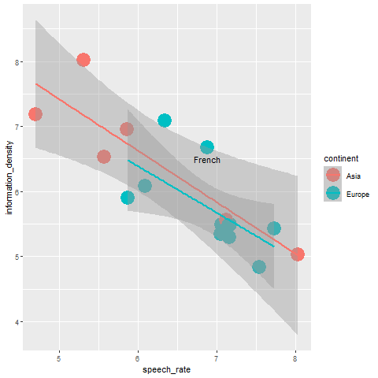

```python
%%R
B <- ggplot(lang,
aes(x= speech_rate, y= information_density, color = continent)
)+geom_point(size = 8) + geom_smooth(method = "lm")+annotate('text', label = "French", y = 6.5, x = 6.88)
B
```

# 3. Language information rate

Oh those results are very interesting… Hmmm I wonder why it looks like that… Ahhh I see what happened, I forgot to include the severe limitations of the feeble human mind in my hypothesis, oh oops you’re still here, ehh well 🪄*obliviate* to you and let’s carry on.

### Question 3.1

rubric={accuracy:3,viz:2}

#### Python

1. It looks like we do not have a language that is high both in information density and speech rate, which could indicate that human minds are not good at processing auditory information beyond a certain rate limit (read more in the article if you're interested). Let’s directly plot the rate at which information is conveyed for all the languages to see if there are at least small differences between them. Combine the appropriate columns to create a new column, `information_rate`, which holds the amount of information per second conveyed by each speaker.
2. Create a plot that has the language ISO codes on one axis and the information rate on the other. Plot a graphical representation of either the distribution of data or every single data point. Color this by the same variable as in the previous two scatter plots. Sort the languages in a suitable order.
3. Include a mark for the mean and the 95% confidence interval on top of the mark you just created above. Color this in a suitable way so that it stands out from the distribution/individual observations created in the previous point.

```python
spoken.head()
```

|  | speaker | iso_lang | text | sex | duration | syllables | age | speech_rate |
| --- | --- | --- | --- | --- | --- | --- | --- | --- |
| 0 | CAT_F1(Su) | CAT | O1 | F | 12.43 | 88 | 42.0 | 7.079646 |
| 1 | CAT_F1(Su) | CAT | O2 | F | 16.92 | 118 | 42.0 | 6.973995 |
| 2 | CAT_F1(Su) | CAT | O3 | F | 19.96 | 139 | 42.0 | 6.963928 |
| 3 | CAT_F1(Su) | CAT | O4 | F | 22.42 | 142 | 42.0 | 6.333631 |
| 4 | CAT_F1(Su) | CAT | O6 | F | 13.49 | 99 | 42.0 | 7.338769 |

```python
# YOUR ANSWER GOES HERE

# create information_rate column
sponek2 = pd.merge(spoken, data, on = "iso_lang", how = "inner")
sponek2["information_rate"] = (sponek2["information_density"] * sponek2["speech_rate"])

points = alt.Chart(sponek2).mark_circle(size=80).encode(
    x=alt.X("iso_lang:N",sort=alt.SortField("information_rate", order="ascending"),title="Language (ISO code)" ),
    y=alt.Y("information_rate:Q", scale=alt.Scale(domain=[20, 65]),title="Information rate (bits per second)" ),
    color=alt.Color("continent:N", title="Continent"),
    tooltip=["language:N", "continent:N","information_rate:Q" ])
points

mean_line = alt.Chart(sponek2).mark_circle(color="black", size = 130).encode(
    x = "iso_lang",
    y="mean(information_rate):Q")

ci = points.transform_regression(
    'iso_lang','information_rate', method='linear'
).mark_circle(color="black", size = 130).encode(
    y='ci0(information_rate):Q',
    y2='ci1(information_rate):Q',
)
plot_C = points + ci + mean_line
plot_C
```

[interactive chart not shown]

### Question 3.2

rubric={accuracy:3,viz:2}

#### R

1. It looks like we do not have a language that is high both in information density and speech rate, which could indicate that human minds are not good at processing auditory information beyond a certain rate limit (read more in the article if you're interested). Let’s directly plot the rate at which information is conveyed for all the languages to see if there are at least small differences between them. Combine the appropriate columns to create a new column, `information_rate`, which holds the amount of information per second conveyed by each speaker.
2. Create a plot that has the language ISO codes on one axis and the information rate on the other. Plot a graphical representation of either the distribution of data or every single data point. Color this by the same variable as in the previous two scatter plots. Sort the languages in a suitable order.
3. Include a mark for the mean and the 95% confidence interval on top of the marks you just created above. Color this in a suitable way so that it stands out from the distribution/individual observations created in the previous point.

```python
%%R
# YOUR ANSWER GOES HERE
spoken2 <- inner_join(lang, spoken, by = "iso_lang")
spoken2$information_rate <- spoken2$information_density * spoken2$speech_rate_individual
```

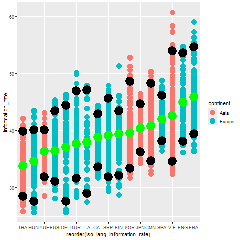

```python
%%R
C <- ggplot(spoken2)+aes(x = reorder(iso_lang, information_rate), y = information_rate, color = continent
    )+geom_point(size = 5) + stat_summary(
    fun = "mean",
    geom = "point",
    color = "green",
    size = 8
  ) +stat_summary(
    fun = ~quantile(., probs = 0.95),
    geom = "point",
    color = "black",
    size = 8
  ) +stat_summary(
    fun = ~quantile(., probs = 0.05),
    geom = "point",
    color = "black",
    size = 8
  )
C
```

# 4. Tell a story

### Question 4

rubric={reasoning:3}

These results are looking pretty promising, now we just need to add a narrative so that it will be easy for others to follow along with what we have done here. Tell a story using the three plots we have created. Build it up according to the principles and examples from this week's required readings. In your story you can refer to the plots as plot A,B, and C. You story should make it clear what the plot is telling us and how it motivates the next plot we're making so that there is a clear story line for the reader to follow as well as a clear take home message (there might be many messages in these plots, so you can choose which to focus on). No need to write an essay here, a succinct paragraph per plot should do it.

Examining plot A we can see that there is a positive linear trend between the amount of distinct syllables and the density of information conveyed of various languages per the continents of Asia and Europe. Within these respective language groups (by continent) we can see that as the number of distinct syllables of languages increases, so does the information density, in a linear fashion. There is one language belonging to the Europe cluster which deviates from this linear trend, having a much greater information density for its given syllables compared to other European languages.

We move onto plot B and observe another linear trend within the language clusters of each continent, this time a negative linear trend. As the speech rate of the languages increase the density of information of the language decreases linearly compared to other languages in its respective continent. This implies that languages that speak faster need to in order to make up for the lack of information conveyed in their words. We do not see any languages both high in information density and speech rate, suggesting a maximum to the amount of info a human can communicate in a given time.

We move to plot C and observe the distribution of information rates (speech rate X information density) of all speakers per each language. We can see that the information rates between languages differ by mean rate from about 35 to 46 across the different languages. There does not appear to be any noticeable difference in info rate between the languages of different continents. There is also a large variation of info rate between speakers of a language suggesting possible variance in info rate between sub groups of languages

# 5. Figure composition

Now that we have the individual figures and the story, the final step for us here is to compile our figures into the same layout for presentation.

### Question 5.1

rubric={accuracy:1,viz:2}

#### Python

1. Assign each of your previous three plots to a variable name (you don’t have to repeat the code down here, you can assign it in the original cell, just make sure you are still outputting the variable at the end of those cells so that the plots still are displayed after each cell).
2. Arrange the three plots into a layout with the two scatter plots in a column to the left and mean + CI plot to the right. The overall layout should look even, so make the scatterplots about half the height and two thirds of the width of the mean + CI plot.
3. Set proper titles where you judge it is needed. Show that you know the proper command to save this as a png file on your local computer.

```python
# YOUR ANSWER GOES HERE
s = """
plot_A = alt.Chart(languages).mark_circle(size=80).encode(
    x=alt.X("distinct_syllables:Q", title="Number of distinct syllables"),
    y=alt.Y("information_density:Q", title="Information density"),
    color=alt.Color("continent:N", title="Continent"),
    tooltip=["language:N", "continent:N"]).properties(width=300,height=200,title="A: Density vs Syllables")
"""
plot_A = plot_A.properties(width = 300, height = 200,title = "Density vs Syllables")


#plot_B = alt.Chart(languages).mark_circle(size=80).encode(
  ##  x=alt.X("speech_rate:Q", title="Speech rate (syll/sec)"),
   # y=alt.Y("information_density:Q", title="Information density"),
  #  color=alt.Color("continent:N", title="Continent"),
  #  tooltip=["language:N", "continent:N"]).properties(width=300, height=200,title="B: Density vs Speech Rate")

plot_B = plot_B.properties(width = 300, height = 200,title = "Density vs Speech Rate")

#points_C = alt.Chart(languages).mark_circle(size=80).encode(
  #  x=alt.X("iso_lang:N", sort=alt.SortField("information_rate", order="ascending"), title="Language (ISO)"),
  #  y=alt.Y("information_rate:Q", title="Information rate (bits/sec)"),
  #  color=alt.Color("continent:N", title="Continent"),
  #  tooltip=["language:N", "continent:N", "information_rate:Q"])
#points_C

mean_line = alt.Chart(languages).mark_rule(color="black",strokeWidth=2).encode(
    y="mean(information_rate):Q")
mean_line

#plot_C = (points_C + mean_line).properties(width=450,height=420,title="C: Information Rate by Language")
plot_C = plot_C.properties(width = 300, height = 400, title = "Information Rate by Language")

left_col = plot_A & plot_B
final_plot = left_col | plot_C

final_plot
```

[interactive chart not shown]

### Question 5.2

rubric={accuracy:1,viz:2}

#### R

1. Assign each of your previous three plots to a variable name (you don’t have to repeat the code down here, you can assign it in the original cell, just make sure you are still outputting the variable at the end of those cells so that the plot shows up).
2. Arrange the three plots into a layout with the two scatter plots to the left and mean + CI plot to the right. The overall layout should look even, so make the scatterplots about half the height and two thirds of the width of the mean + CI plot.
3. Set proper titles where you think it is needed, and remove and superfluous legends. Show that you know the proper command to save this as a png file on your local computer.

Question 1 is done in the previous questions

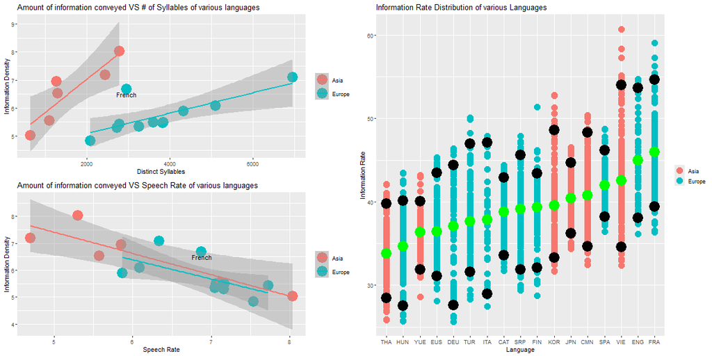

```python
%%R -w 1200 -h 600
# YOUR ANSWER GOES HERE
A <- A + labs(title = "Amount of information conveyed VS # of Syllables of various languages",
             x = 'Distinct Syllables', y='Information Density') + theme(legend.title = element_blank())

B <- B + labs(title = "Amount of information conveyed VS Speech Rate of various languages ",
             x = 'Speech Rate', y='Information Density') + theme(legend.title = element_blank())

C <- C + labs(title = "Information Rate Distribution of various Languages",
             x = 'Language', y='Information Rate') + theme(legend.title = element_blank())

library(cowplot)
left <- plot_grid(A, B, ncol = 1)
plot_grid(left, C)
```

Thank you, this has certainly been educational. I'll present these results to the intergalactic ministry of traffic and hopefully we can spare earth from the hyperspace bypass this time around... ah shoot, me and my big mouth! Basically there is nothing to worry about, you just keep squabbling amongst each other over lines in the sand and hopefully you wont hear from us again. So long and thanks for all the fish! 🛸🐬

# 6. Presenting figures to a general or a technical audience

Below you can see the original figure from [the scientific article in “Science Advances”](https://www.science.org/doi/10.1126/sciadv.aaw2594) and the [simplified version that was published in the Economist](https://www.economist.com/graphic-detail/2019/09/28/why-are-some-languages-spoken-faster-than-others) (you can create a free account to read the article, no need to pay or use the trial). There is also an R Markdown file for how they did their analysis in the article supplementary materials in case you're interested.

### Question 6 (Optional)

rubric={reasoning:1.5}

1. Briefly describe how the Economist have simplified the figure from the original scientific publication.
2. Do you agree with choices made by the Economist? Is there anything you think could have been done differently or additionally, that would have communicated the findings more clearly to a general / popular science audience? This could be based on design choices or your understanding of the data.

## Scientific figure

[figure not shown]

## Popular science figure

[figure not shown]